# Winner plc- Testing for Salary Discrimination

Write your name here

2025-01-21

# Introduction

This workshop does not have step-by-step guidelines. It gives you a good exercise in building regression models and illustrates the link between confidence intervals, hypothesis testing, and regression.

At the last board meeting of Winner Plc., the headquarters of a large multinational company, the issue was raised that women were being discriminated in the company, in the sense that the salaries were not the same for male and female executives. A quick analysis of a sample of 50 employees (of which 24 men and 26 women) revealed that the average salary for men was about ?8,400 higher than for women. This seemed like a considerable difference, so it was decided that a further analysis of the company salaries was warranted.

You are asked to carry out the analysis. The objective is to find out whether there is indeed a significant difference between the salaries of men and women, and whether the difference is due to discrimination or whether it is based on another, possibly valid, determining factor. As part of this assignment, 4 out of the 10 questions on concept check 2 relate to this case.

# Salary on Gender

The data frame `winner` contains the salaries for the sample of 50 executives in the company. Can you conclude that there is a significant difference between the salaries of the male and female executives?

Note that you can perform different types of analyses, and check whether they all lead to the same conclusion

- Confidence intervals
- Hypothesis testing
- Correlation analysis
- Regression

## Visualisations

First lets us draw a density plot (smoothed histogram) and a boxplot to look at the distribution of salaries by gender. Rememebr that the line in the middle of each box is the median, not the mean.

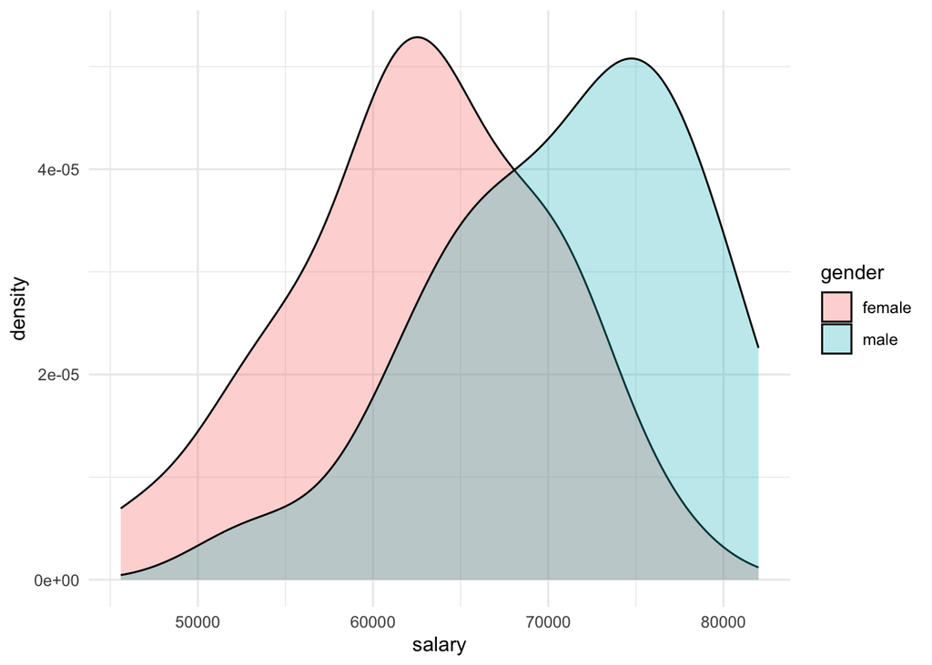

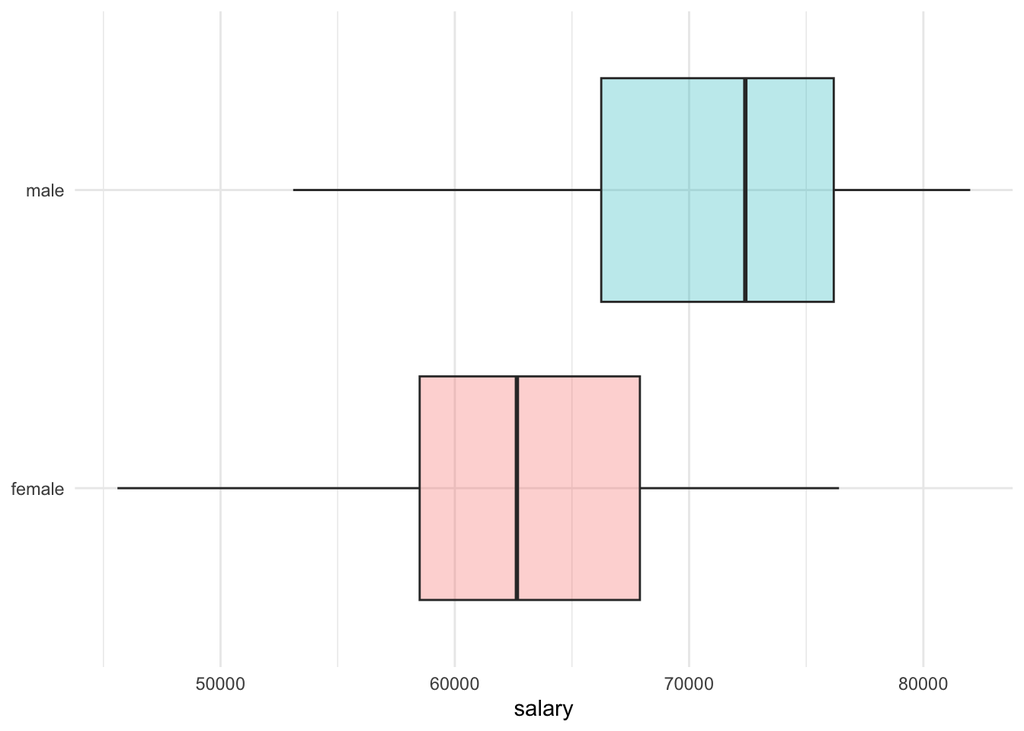

## Summary statistics

The following table provides sumamry statistics. Confirm that the standard error (se) is equal to
$$se =
sd/sqrt(n)$$

| gender | min | Q1 | median | Q3 | max | mean | sd | n | se |
| --- | --- | --- | --- | --- | --- | --- | --- | --- | --- |
| female | 45600 | 58500 | 62650 | 67900 | 76400 | 62577 | 7336.8 | 26 | 1438.9 |
| male | 53100 | 66250 | 72400 | 76175 | 82000 | 71008 | 7235.3 | 24 | 1476.9 |

The observed mean salary difference between men and women is delta* = 62577 - 71008 = -8431

## Confidence Intervals

> Can you create the 95, 99, and 99.9% confindence intervals ‘by hand’?

### 95% CI

```r
# t-Critical values for 95% intervals for male (n=24) and female (n=26) salaries
qt(0.975, 23)  # t-critical for male
```

```
## [1] 2.0687
```

```r
qt(0.975, 25)  # t-critical for female
```

```
## [1] 2.0595
```

### 99% CI

```r
# t-Critical values for 99% intervals for male (n=24) and female (n=26) salaries
qt(0.995, 23)  # t-critical for male
```

```
## [1] 2.8073
```

```r
qt(0.995, 25)  # t-critical for female
```

```
## [1] 2.7874
```

### 99.9% CI

```r
# t-Critical values for 99.9% intervals for male (n=24) and female (n=26) salaries
qt(0.9995, 23)  # t-critical for male
```

```
## [1] 3.7676
```

```r
qt(0.9995, 25)  # t-critical for female
```

```
## [1] 3.7251
```

## Hypothesis testing

We can also run a a hypothesis testing, assuming as a null hypothesis that the mean difference in salaries is zero, or that, on average, men and women make the same amount of money.

```r
t.test(salary ~ gender, data = winner)
```

```
##
##  Welch Two Sample t-test
##
## data:  salary by gender
## t = -4.09, df = 47.8, p-value = 0.00017
## alternative hypothesis: true difference in means between group female and group male is not equal to 0
## 95 percent confidence interval:
##  -12577.7  -4285.1
## sample estimates:
## mean in group female   mean in group male
##                62577                71008
```

> Is the difference in salaries statistically significant? Why?

## Regression

```r
model1 <- lm(salary ~ gender, data = winner)
msummary(model1)
```

```
##             Estimate Std. Error t value Pr(>|t|)
## (Intercept)    62577       1429   43.78  < 2e-16 ***
## gendermale      8431       2063    4.09  0.00017 ***
##
## Residual standard error: 7290 on 48 degrees of freedom
## Multiple R-squared:  0.258,  Adjusted R-squared:  0.243
## F-statistic: 16.7 on 1 and 48 DF,  p-value: 0.000165
```

> What is the slope of `genderMale`? Is it similar to something you have seen before?

# Experience on Gender

At the board meeting, someone raised the issue that there was indeed a substantial difference between male and female salaries, but that this was attributable to other reasons such as differences in experience. A questionnaire send out to the 50 executives in the sample reveals that the average experience of the men is approximately 21 years, whereas the women only have about 7 years experience on average (see table below).

## Visualisations

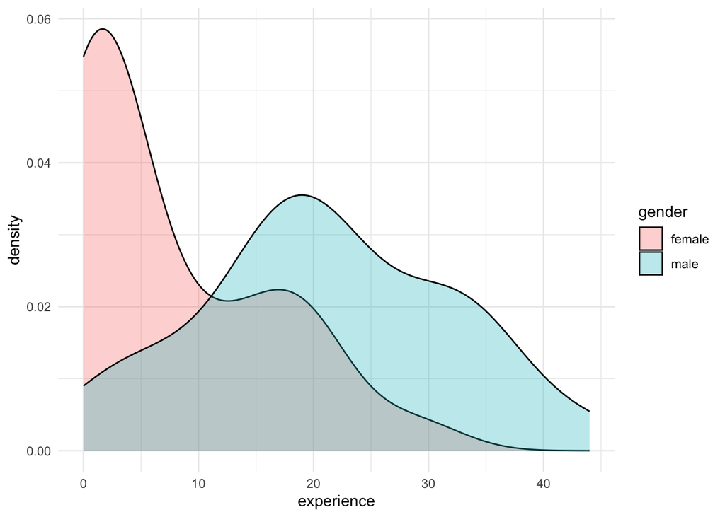

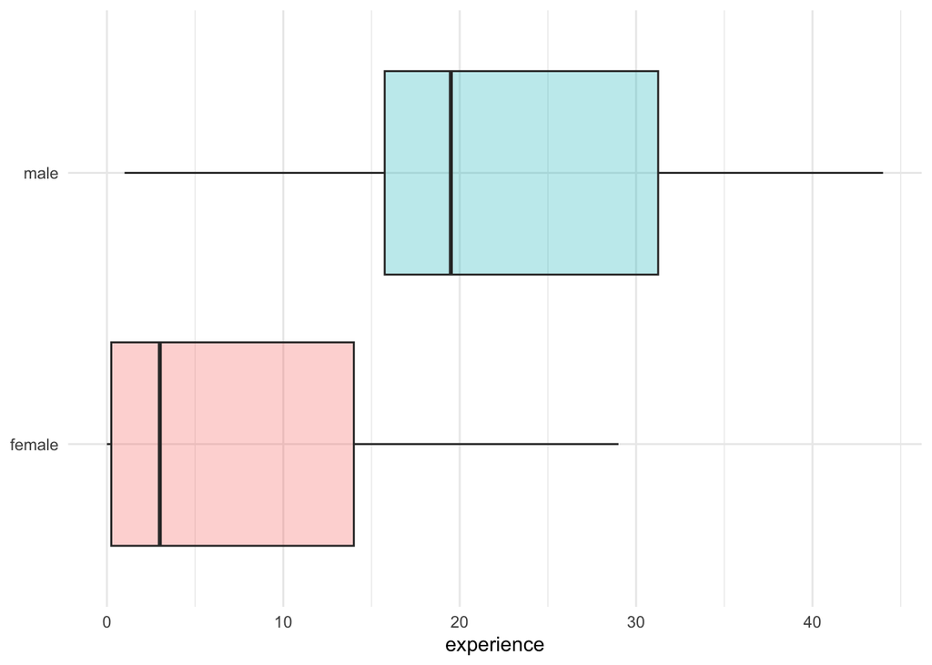

## Summary statistics

| gender | min | Q1 | median | Q3 | max | mean | sd | n | se |
| --- | --- | --- | --- | --- | --- | --- | --- | --- | --- |
| female | 0 | 0.25 | 3.0 | 14.00 | 29 | 7.3846 | 8.5139 | 26 | 1.6697 |
| male | 1 | 15.75 | 19.5 | 31.25 | 44 | 21.1250 | 10.9159 | 24 | 2.2282 |

> Can you construct two 95% CIs for the mean experience of men and women?

```r
t.test(experience ~ gender, data = winner)
```

```
##
##  Welch Two Sample t-test
##
## data:  experience by gender
## t = -4.93, df = 43.5, p-value = 1.2e-05
## alternative hypothesis: true difference in means between group female and group male is not equal to 0
## 95 percent confidence interval:
##  -19.3539  -8.1269
## sample estimates:
## mean in group female   mean in group male
##               7.3846              21.1250
```

> Based on this evidence, can you conclude that there is a significant difference between the experience of the male and female executives? Perform similar analyses as in the previous section. Does your conclusion validate or endanger your conclusion about the difference in male and female salaries?

# Salary on Experience

Someone at the meeting argues that clearly, a more thorough analysis of the relationship between salary and experience is required before any conclusion can be drawn about whether there is any gender-based salary discrimination in the company.

Analyse the relationship between salary and experience. What can you conclude?

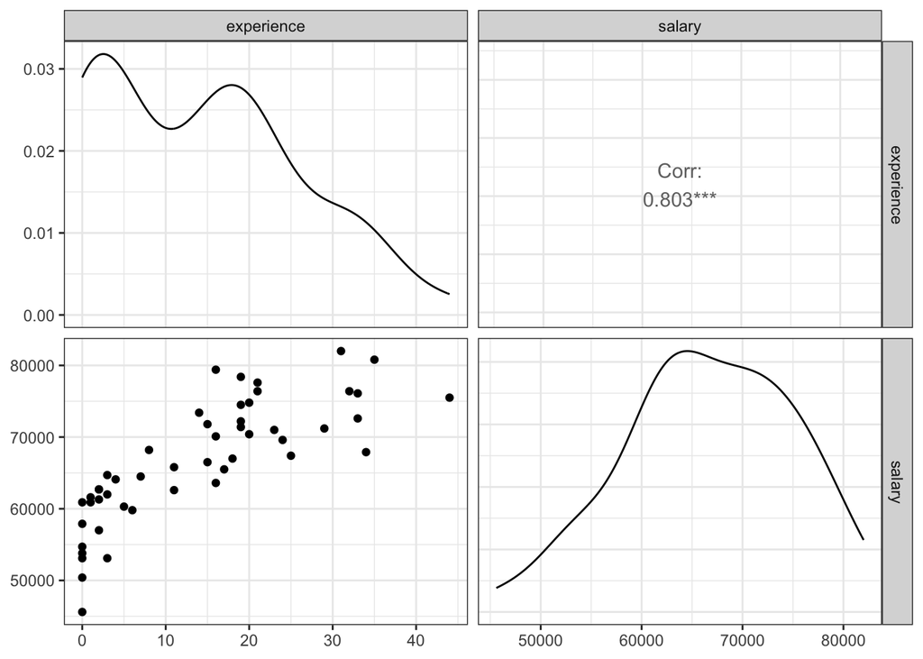

## Develop a sensible regression model

```r
# fit a linear model (lm) of salary on experience
model2 <- lm(salary ~ experience , data=winner)
msummary(model2)
```

```
##             Estimate Std. Error t value Pr(>|t|)
## (Intercept)  58704.8     1107.8   52.99  < 2e-16 ***
## experience     566.5       60.7    9.34  2.3e-12 ***
##
## Residual standard error: 5040 on 48 degrees of freedom
## Multiple R-squared:  0.645,  Adjusted R-squared:  0.638
## F-statistic: 87.2 on 1 and 48 DF,  p-value: 2.26e-12
```

> Write down the obtained equation, interpret it (“What does it mean?”) and see whether it makes sense.

### Check the goodness-of-fit

> Evaluate (adjusted) R2. What proportion of the overall variability in salary does our model explain?

### Examine significance of variables

> Evaluate t-values or p-values, and remove insignificant variables

# Salary on Gender + Experience

Extend your analysis of the previous section to investigate whether there is salary discrimination based on gender or not.

To run a multiple regression model in R, use `lm( Y ~ X1 + X2 + X3, data= .)`

```r
model3 <- lm(salary ~ experience + gender, data=winner)
msummary(model3)
```

```
##             Estimate Std. Error t value Pr(>|t|)
## (Intercept)  58574.0     1140.5   51.36   <2e-16 ***
## experience     542.1       75.3    7.20    4e-09 ***
## gendermale     983.2     1770.8    0.56     0.58
##
## Residual standard error: 5080 on 47 degrees of freedom
## Multiple R-squared:  0.647,  Adjusted R-squared:  0.632
## F-statistic: 43.1 on 2 and 47 DF,  p-value: 2.3e-11
```

## Colinearity

> Check for multicollinearity (i.e. correlated independent variables), and remove correlated independent variables from the model.

```r
vif(model3)
```

```
## experience     gender
##     1.5175     1.5175
```

No VIFs are greater than 5, so we do not have any colinearity issues… but `gender` is no longer significant, so let us remove it from the regression.

```r
model4 <- lm(salary ~ experience, data=winner)
msummary(model4)
```

```
##             Estimate Std. Error t value Pr(>|t|)
## (Intercept)  58704.8     1107.8   52.99  < 2e-16 ***
## experience     566.5       60.7    9.34  2.3e-12 ***
##
## Residual standard error: 5040 on 48 degrees of freedom
## Multiple R-squared:  0.645,  Adjusted R-squared:  0.638
## F-statistic: 87.2 on 1 and 48 DF,  p-value: 2.26e-12
```

# Improving the Model

Again at the meeting, someone was looking at the results of the analysis of salary versus experience, and said that it was to be expected that an employee with more experience than another employee would have a higher salary. However, he argued that the difference in salary between two people with 2 and 4 years experience would be higher than the difference in salary between two people with 26 and 28 years experience!

> Can you find any indication that this is the case? If yes, how can you modify your analysis to take this into account?

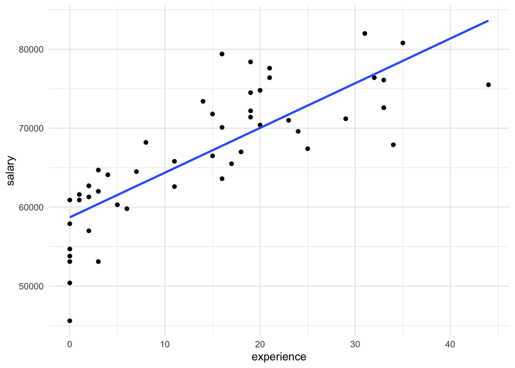

```r
#let us look at the scatterplot of experience on salary, and add a linear trendline
ggplot(winner, aes(x=experience, y = salary))+
  geom_point()+
  geom_smooth(method = "lm", se=FALSE)+
  theme_minimal()
```

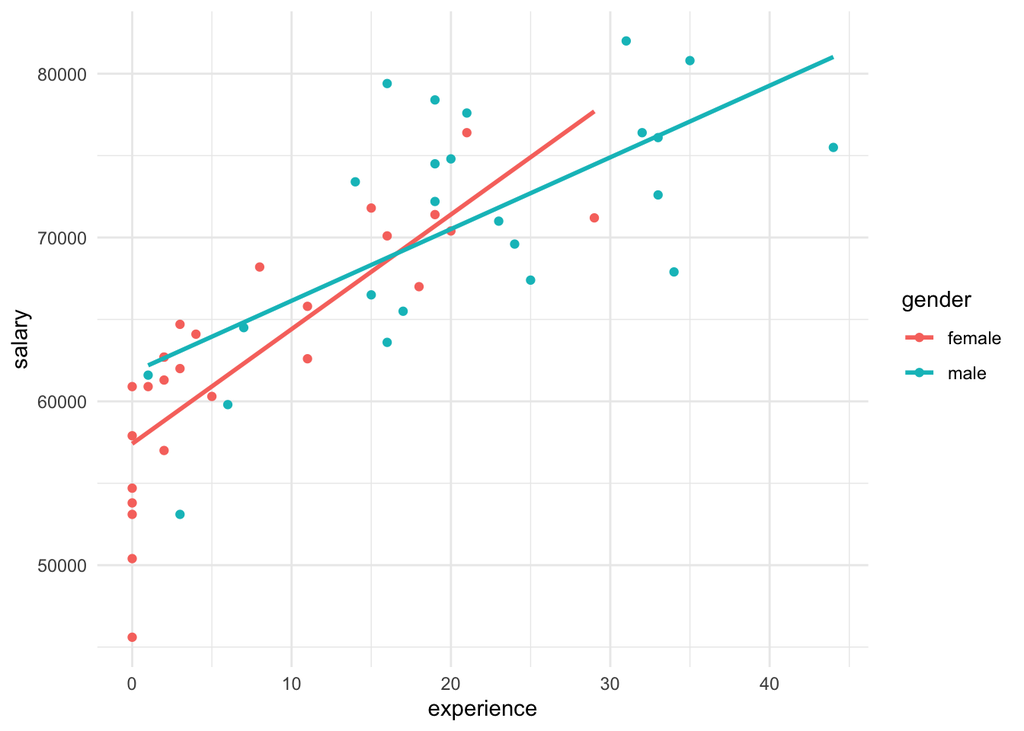

```r
#let us look at the scatterplot of experience on salary, coloured by gender
ggplot(winner, aes(x=experience, y = salary, colour = gender))+
  geom_point()+
  geom_smooth(method = "lm", se=FALSE)+
  theme_minimal()
```

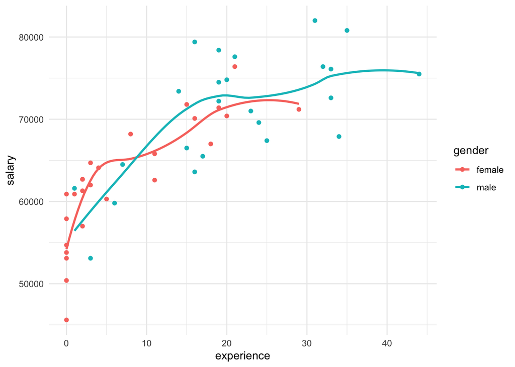

```r
# What if its not a straight line?
# use geom_smooth() to let R fit what it thinks looks like the best line
ggplot(winner, aes(x=experience, y = salary, colour = gender))+
  geom_point()+
  geom_smooth(se=FALSE)+
  theme_minimal()
```

```r
# R's best geom_smooth() line seems to show that in early years salary increases fast,
# but after about 10-15 years, the increase in salary for an additional year of
# experience slows down.

# This look like a square root (sqrt) relationship, so let us try this.

model5 <- lm(salary ~ sqrt(experience) + gender, data = winner)
mosaic::msummary(model5)
```

```
##                  Estimate Std. Error t value Pr(>|t|)
## (Intercept)       54759.1     1196.3   45.78  < 2e-16 ***
## sqrt(experience)   3713.7      397.6    9.34  2.8e-12 ***
## gendermale          -73.4     1533.3   -0.05     0.96
##
## Residual standard error: 4360 on 47 degrees of freedom
## Multiple R-squared:  0.74,   Adjusted R-squared:  0.729
## F-statistic:   67 on 2 and 47 DF,  p-value: 1.74e-14
```

```r
car::vif(model5)
```

```
## sqrt(experience)           gender
##           1.5448           1.5448
```

```r
# no colinearity, but gender is not significant, so remove and rerun
model6 <- lm(salary ~ sqrt(experience), data = winner)
mosaic::msummary(model6)
```

```
##                  Estimate Std. Error t value Pr(>|t|)
## (Intercept)         54760       1184    46.3  < 2e-16 ***
## sqrt(experience)     3702        317    11.7  1.2e-15 ***
##
## Residual standard error: 4310 on 48 degrees of freedom
## Multiple R-squared:  0.74,   Adjusted R-squared:  0.735
## F-statistic:  137 on 1 and 48 DF,  p-value: 1.18e-15
```

## Comparing Models

Assess and compare different models to see which one is most sensible and fits the data best.

Comparison of models

|  | (1) | (2) | (3) | (4) | (5) | (6) |
| --- | --- | --- | --- | --- | --- | --- |
| (Intercept) | 62576.923 | 58704.761 | 58573.976 | 58704.761 | 54759.062 | 54760.048 |
|  | (1429.358) | (1107.810) | (1140.468) | (1107.810) | (1196.251) | (1183.578) |
| gendermale | 8431.410 |  | 983.217 |  | -73.424 |  |
|  | (2063.101) |  | (1770.760) |  | (1533.267) |  |
| experience |  | 566.469 | 542.066 | 566.469 |  |  |
|  |  | (60.651) | (75.259) | (60.651) |  |  |
| sqrt(experience) |  |  |  |  | 3713.738 | 3702.431 |
|  |  |  |  |  | (397.589) | (316.551) |
| #observations | 50 | 50 | 50 | 50 | 50 | 50 |
| R squared | 0.258 | 0.645 | 0.647 | 0.645 | 0.740 | 0.740 |
| Adj. R Squared | 0.243 | 0.638 | 0.632 | 0.638 | 0.729 | 0.735 |
| Residual SE | 7288.325 | 5041.344 | 5078.065 | 5041.344 | 4358.079 | 4312.548 |